# 4.1 Distribuciones

Luis Roca

3/5/2021

```r
library(tidyverse)
```

## A. Variables aleatorias discretas:

### A.1. Distribucion Binomial

Su función es **rbinom(n, size, prob)**, donde: * n, numero de observaciones * size, es el numero de pruebas realizadas (cero o más) * prob, probabilidad de exito para cada prueba realizada * Documentación https://www.rdocumentation.org/packages/stats/versions/3.6.2/topics/Binomial

Ejemplo:

```r
Simulacion_binomial <- rbinom(100, 30, 0.2)
```

### A.2. Distribucion Poisson

Su función es **rpois(n, lambda)**, donde: * n, número de valores aleatorios de regreso * lambda, valor de lambda (se espera un vector)  
* Documentación: https://www.rdocumentation.org/packages/stats/versions/3.6.2/topics/Poisson

Ejemplo:

```r
Simulacion_Poisson <- rpois(100, 1)
?rpois
```

[output not shown]

### Resumen de variables aleatorias discretas

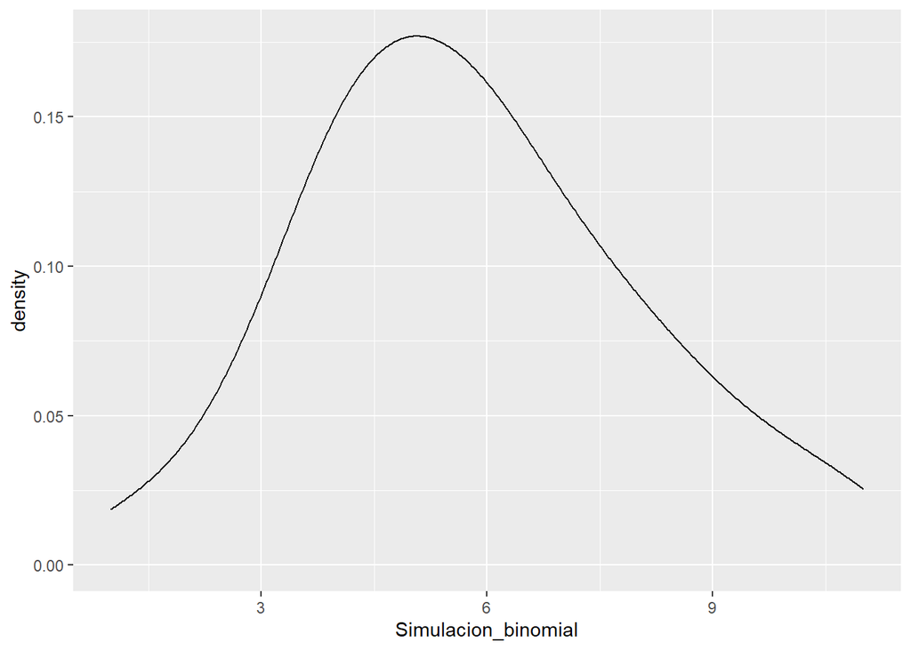

```r
Variables_A.Discretas <- as.data.frame(cbind(Simulacion_binomial, Simulacion_Poisson))

ggplot(Variables_A.Discretas)+
  geom_density(aes(x=Simulacion_binomial))
```

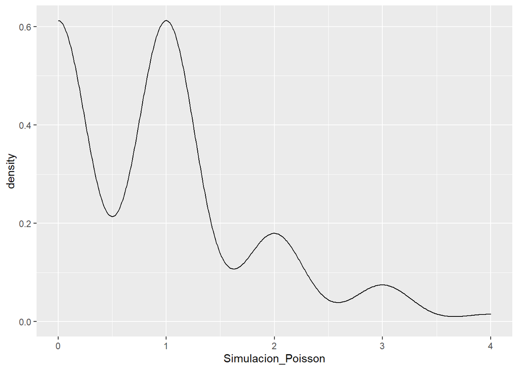

```r
ggplot(Variables_A.Discretas)+
  geom_density(aes(x=Simulacion_Poisson))
```

## B. Variables aleatorias continuas:

### B.1. Distribucion Normal

Su función es **rnorm(n, mean = 0, sd = 1)**, donde: * n es el numero de observaciones * mean es el valor de la media poblacional * sd, es la desviación estándar poblacional * Documentación: https://www.rdocumentation.org/packages/stats/versions/3.6.2/topics/Normal

Ejemplo:

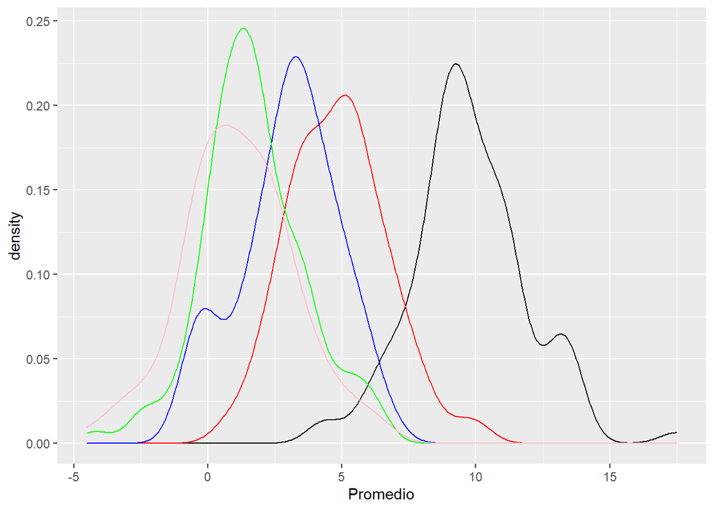

```r
Simulacion_Normal <- data.frame(Normal_1 = rnorm(100, mean = 10, sd =2),
                                Normal_2 = rnorm(100, mean = 5, sd =2),
                                Normal_3 = rnorm(100, mean = 3, sd =2),
                                Normal_4 = rnorm(100, mean = 2, sd =2),
                                Normal_5 = rnorm(100, mean = 1, sd =2))

ggplot(Simulacion_Normal)+
  geom_density(aes(x=Normal_1))+
  geom_density(aes(x=Normal_2),color = "red")+
  geom_density(aes(x=Normal_3),color = "blue")+
  geom_density(aes(x=Normal_4),color = "green")+
  geom_density(aes(x=Normal_5),color = "pink")+
  xlab("Promedio")
```

### B.2. Distribucion Exponencial

Su función es **rexp(n, rate = 1)**. Donde: n, numero de observaciones rate, tasa de vectores https://www.rdocumentation.org/packages/stats/versions/3.6.2/topics/Exponential

Ejemplo:

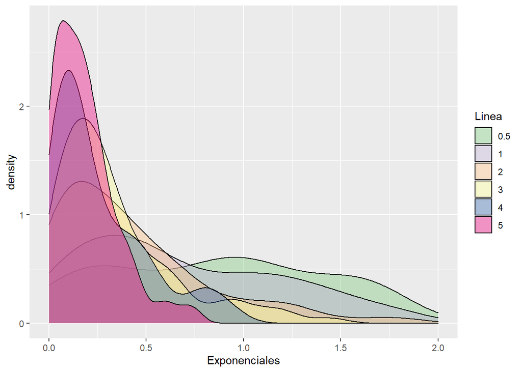

```r
library(colourpicker)
Simulacion_Exponencial <- data.frame(Linea = c(replicate(100,"0.5"),replicate(100,"1"),
                                               replicate(100,"2"),replicate(100, "3"),
                                               replicate(100,"4"), replicate(100, "5"),
                                               replicate(100,"6")),
                                     Exponenciales =c(rexp(100, rate = 0.5),
                                                      rexp(100, rate = 1),
                                                      rexp(100, rate = 2),
                                                      rexp(100, rate = 3),
                                                      rexp(100, rate = 4),
                                                      rexp(100, rate = 5),
                                                      rexp(100, rate = 6)))


Simulacion_Exponencial %>%
  filter(Linea %in% c("0.5", "1", "2", "3", "4", "5")) %>%
  ggplot()+
  geom_density(aes(x=Exponenciales, fill = Linea), alpha=0.4)+
  scale_x_continuous(limits = c(0, 2))+
  scale_fill_brewer(palette="Accent")
```

### B.3. Distribucion Chi-cuadrado

Su función es **rchisq(n, df, ncp = 0)**, donde: * n, numero de observaciones * df, grados de libertad * ncp, parámetro de no centralidad (no negativo) * https://www.rdocumentation.org/packages/stats/versions/3.6.2/topics/Chisquare

Ejemplo:

```r
Simulacion_chi <- rchisq(100, 10, ncp = 0)
```

### B.4. Distribucion t-Student

Su función es **rt(n, df, ncp)**, donde: * n, numero de observaciones * df, grados de libertad * ncp, parámetros no centrales (si se omite, se asume la distribución central de t) * https://www.rdocumentation.org/packages/stats/versions/3.6.2/topics/TDist

Ejemplo:

```r
Simulacion_student <- rt(100, 10, 0)
```

### B.5. Distribucion de Snedecor F

Su función es **rf(n, df1, df2, ncp)**, donde: * n, numero de observaciones * df1, grados de libertad * df2, grados de libertad * ncp, parámetros no centrales (si se omite, se asume la distribución central de F) * https://www.rdocumentation.org/packages/stats/versions/3.6.2/topics/FDist

Ejemplo:

```r
Simulacion_F <- rf(100, 10, 12, 0)
```